# Machine Learning Algorithms

```r
table(nc$Best.n[1,])
```

```
##
##  0  1  2  3 10 12 14 15
##  2  1  4 15  1  1  1  1
```

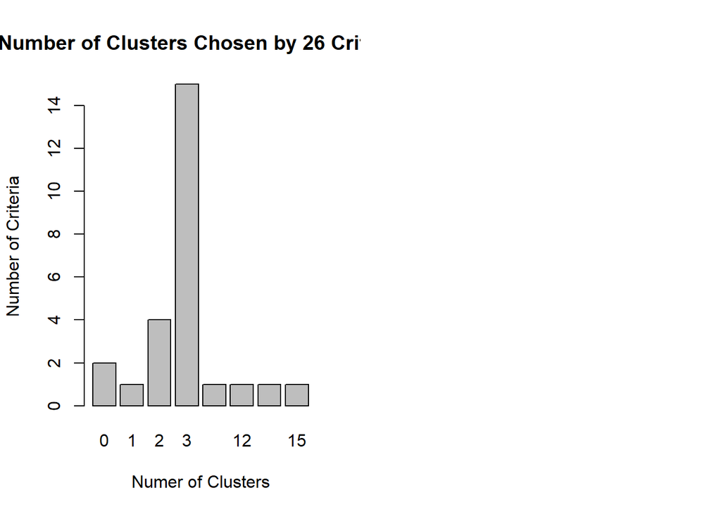

```r
barplot(table(nc$Best.n[1,]),
        xlab="Numer of Clusters", ylab="Number of Criteria",
        main="Number of Clusters Chosen by 26 Criteria")
```

We take 3 clusters

```r
set.seed(1234)
fit.km <- kmeans(df, 3, nstart=25)                           #3

# Size of the clusters
fit.km$size
```

```
## [1] 62 65 51
```

```r
# Centroid of the clusters
fit.km$centers
```

```
##      Alcohol      Malic        Ash Alcalinity   Magnesium     Phenols
## 1  0.8328826 -0.3029551  0.3636801 -0.6084749  0.57596208  0.88274724
## 2 -0.9234669 -0.3929331 -0.4931257  0.1701220 -0.49032869 -0.07576891
## 3  0.1644436  0.8690954  0.1863726  0.5228924 -0.07526047 -0.97657548
##    Flavanoids Nonflavanoids Proanthocyanins      Color        Hue
## 1  0.97506900   -0.56050853      0.57865427  0.1705823  0.4726504
## 2  0.02075402   -0.03343924      0.05810161 -0.8993770  0.4605046
## 3 -1.21182921    0.72402116     -0.77751312  0.9388902 -1.1615122
##     Dilution    Proline
## 1  0.7770551  1.1220202
## 2  0.2700025 -0.7517257
## 3 -1.2887761 -0.4059428
```

```r
aggregate(wine[-1], by=list(cluster=fit.km$cluster), mean)
```

```
##   cluster  Alcohol    Malic      Ash Alcalinity Magnesium  Phenols
## 1       1 13.67677 1.997903 2.466290   17.46290 107.96774 2.847581
## 2       2 12.25092 1.897385 2.231231   20.06308  92.73846 2.247692
## 3       3 13.13412 3.307255 2.417647   21.24118  98.66667 1.683922
##   Flavanoids Nonflavanoids Proanthocyanins    Color       Hue Dilution
## 1  3.0032258     0.2920968        1.922097 5.453548 1.0654839 3.163387
## 2  2.0500000     0.3576923        1.624154 2.973077 1.0627077 2.803385
## 3  0.8188235     0.4519608        1.145882 7.234706 0.6919608 1.696667
##     Proline
## 1 1100.2258
## 2  510.1692
## 3  619.0588
```

```r
ct.km <- table(wine$Type, fit.km$cluster)
ct.km
```

```
##
##      1  2  3
##   1 59  0  0
##   2  3 65  3
##   3  0  0 48
```

```r
library(flexclust)
randIndex(ct.km)
```

```
##      ARI
## 0.897495
```

### 9. Random Forest

Random Forest is a trademark term for an ensemble of decision trees. In Random Forest, we’ve collection of decision trees (so known as “Forest”). To classify a new object based on attributes, each tree gives a classification and we say the tree “votes” for that class. The forest chooses the classification having the most votes (over all the trees in the forest).

Each tree is planted & grown as follows:

1. If the number of cases in the training set is N, then sample of N cases is taken at random but with replacement. This sample will be the training set for growing the tree.
2. If there are M input variables, a number m<<M is specified such that at each node, m variables are selected at random out of the M and the best split on these m is used to split the node. The value of m is held constant during the forest growing.
3. Each tree is grown to the largest extent possible. There is no pruning.

```r
# Load the party package. It will automatically load other
# required packages.
library(party)
library(randomForest)
# Create the forest.
output.forest <- randomForest(nativeSpeaker ~ age + shoeSize + score,
           data = readingSkills)

# View the forest results.
output.forest
```

```
##
## Call:
##  randomForest(formula = nativeSpeaker ~ age + shoeSize + score,      data = readingSkills)
##                Type of random forest: classification
##                      Number of trees: 500
## No. of variables tried at each split: 1
##
##         OOB estimate of  error rate: 0.5%
## Confusion matrix:
##     no yes class.error
## no  99   1        0.01
## yes  0 100        0.00
```

```r
# Importance of each predictor.
importance(output.forest,type = 2)
```

```
##          MeanDecreaseGini
## age              13.76032
## shoeSize         18.94605
## score            58.86071
```

### 10. PCA (Principal Component Analysis)

PCA is a statistical procedure that uses an orthogonal transformation to convert a set of observations of possibly correlated variables into a set of values of linearly uncorrelated variables called principal components.

```r
#Taking the numeric part of the IRIS data
data_iris <- iris[1:4]

#Calculating the covariance matrix
Cov_data <- cov(data_iris )

#Find out the eigenvectors and eigenvalues using the covariance matrix
Eigen_data <- eigen(Cov_data)

#Using the inbuilt function
PCA_data <- princomp(data_iris ,cor="False")

#Let's now compare the output variances
Eigen_data$values #The output is 4.22824171 0.24267075 0.07820950 0.02383509
```

```
## [1] 4.22824171 0.24267075 0.07820950 0.02383509
```

```r
PCA_data$sdev^2 #The output is 4.20005343 0.24105294 0.07768810 0.02367619
```

```
##     Comp.1     Comp.2     Comp.3     Comp.4
## 4.20005343 0.24105294 0.07768810 0.02367619
```

```r
PCA_data$loadings[,1:4]
```

```
##                   Comp.1      Comp.2      Comp.3     Comp.4
## Sepal.Length  0.36138659  0.65658877  0.58202985  0.3154872
## Sepal.Width  -0.08452251  0.73016143 -0.59791083 -0.3197231
## Petal.Length  0.85667061 -0.17337266 -0.07623608 -0.4798390
## Petal.Width   0.35828920 -0.07548102 -0.54583143  0.7536574
```

```r
Eigen_data$vectors
```

```
##             [,1]        [,2]        [,3]       [,4]
## [1,]  0.36138659 -0.65658877 -0.58202985  0.3154872
## [2,] -0.08452251 -0.73016143  0.59791083 -0.3197231
## [3,]  0.85667061  0.17337266  0.07623608 -0.4798390
## [4,]  0.35828920  0.07548102  0.54583143  0.7536574
```

```r
summary(PCA_data)
```

```
## Importance of components:
##                           Comp.1     Comp.2     Comp.3      Comp.4
## Standard deviation     2.0494032 0.49097143 0.27872586 0.153870700
## Proportion of Variance 0.9246187 0.05306648 0.01710261 0.005212184
## Cumulative Proportion  0.9246187 0.97768521 0.99478782 1.000000000
```

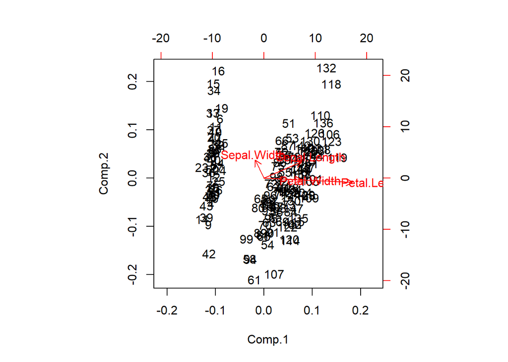

```r
biplot (PCA_data)
```

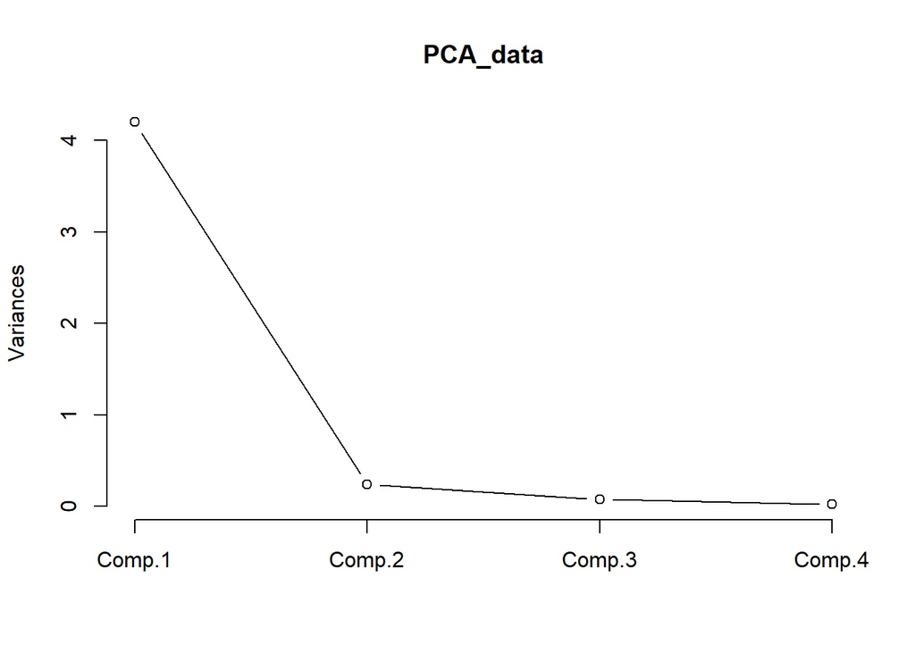

```r
screeplot(PCA_data, type="lines")
```

```r
#Select the first principal component for the second model
model2 = PCA_data$loadings[,1]
#For the second model, we need to calculate scores by multiplying our loadings with the data
model2_scores <- as.matrix(data_iris) %*% model2

#Loading libraries for naiveBayes model
library(class)
library(e1071)

#Fitting the first model over the entire data
mod1<-naiveBayes(iris[,1:4], iris[,5])
#Fitting the second model using the first principal component
mod2<-naiveBayes(model2_scores, iris[,5])

#Accuracy for the first model
table(predict(mod1, iris[,1:4]), iris[,5])
```

```
##
##              setosa versicolor virginica
##   setosa         50          0         0
##   versicolor      0         47         3
##   virginica       0          3        47
```

```r
#Accuracy for the second model
table(predict(mod2, model2_scores), iris[,5])
```

```
##
##              setosa versicolor virginica
##   setosa         50          0         0
##   versicolor      0         46         5
##   virginica       0          4        45
```